## Activity Analysis

```r
fig.path = getwd()
fig.show = 'asis'
```

```r
library(dplyr)
library(xtable)
library(ggplot2)
```

#### This code is used to import the data set and convert the class of data in the date column to type Date.

#### Assumes all of the necessary files are in your working directory

```r
activity <- read.csv('activity.csv', header = TRUE, stringsAsFactors = FALSE)
activity$date <- as.Date(activity$date, '%Y-%m-%d')
```

#### Next we are going to determine the number of steps taken per day and calculate the mean and median number of steps per day.

#### Note that NA values are excluded.

```r
#Remove NA data
activity1 <- activity[!is.na(activity$steps),]

#Group the data by date and sum the number of steps for each day
activitySummary <- activity1 %>% group_by(date) %>% summarise(NumSteps = sum(steps), StepMean = mean(steps), StepMedian = median(steps))
```

#### Then we show the total steps, mean, and median steps per day

```r
xt <- xtable(activitySummary)
print(xt, type = 'html')
```

|  | date | NumSteps | StepMean | StepMedian |
| --- | --- | --- | --- | --- |
| 1 | 15615.00 | 126 | 0.44 | 0.00 |
| 2 | 15616.00 | 11352 | 39.42 | 0.00 |
| 3 | 15617.00 | 12116 | 42.07 | 0.00 |
| 4 | 15618.00 | 13294 | 46.16 | 0.00 |
| 5 | 15619.00 | 15420 | 53.54 | 0.00 |
| 6 | 15620.00 | 11015 | 38.25 | 0.00 |
| 7 | 15622.00 | 12811 | 44.48 | 0.00 |
| 8 | 15623.00 | 9900 | 34.38 | 0.00 |
| 9 | 15624.00 | 10304 | 35.78 | 0.00 |
| 10 | 15625.00 | 17382 | 60.35 | 0.00 |
| 11 | 15626.00 | 12426 | 43.15 | 0.00 |
| 12 | 15627.00 | 15098 | 52.42 | 0.00 |
| 13 | 15628.00 | 10139 | 35.20 | 0.00 |
| 14 | 15629.00 | 15084 | 52.38 | 0.00 |
| 15 | 15630.00 | 13452 | 46.71 | 0.00 |
| 16 | 15631.00 | 10056 | 34.92 | 0.00 |
| 17 | 15632.00 | 11829 | 41.07 | 0.00 |
| 18 | 15633.00 | 10395 | 36.09 | 0.00 |
| 19 | 15634.00 | 8821 | 30.63 | 0.00 |
| 20 | 15635.00 | 13460 | 46.74 | 0.00 |
| 21 | 15636.00 | 8918 | 30.97 | 0.00 |
| 22 | 15637.00 | 8355 | 29.01 | 0.00 |
| 23 | 15638.00 | 2492 | 8.65 | 0.00 |
| 24 | 15639.00 | 6778 | 23.53 | 0.00 |
| 25 | 15640.00 | 10119 | 35.14 | 0.00 |
| 26 | 15641.00 | 11458 | 39.78 | 0.00 |
| 27 | 15642.00 | 5018 | 17.42 | 0.00 |
| 28 | 15643.00 | 9819 | 34.09 | 0.00 |
| 29 | 15644.00 | 15414 | 53.52 | 0.00 |
| 30 | 15646.00 | 10600 | 36.81 | 0.00 |
| 31 | 15647.00 | 10571 | 36.70 | 0.00 |
| 32 | 15649.00 | 10439 | 36.25 | 0.00 |
| 33 | 15650.00 | 8334 | 28.94 | 0.00 |
| 34 | 15651.00 | 12883 | 44.73 | 0.00 |
| 35 | 15652.00 | 3219 | 11.18 | 0.00 |
| 36 | 15655.00 | 12608 | 43.78 | 0.00 |
| 37 | 15656.00 | 10765 | 37.38 | 0.00 |
| 38 | 15657.00 | 7336 | 25.47 | 0.00 |
| 39 | 15659.00 | 41 | 0.14 | 0.00 |
| 40 | 15660.00 | 5441 | 18.89 | 0.00 |
| 41 | 15661.00 | 14339 | 49.79 | 0.00 |
| 42 | 15662.00 | 15110 | 52.47 | 0.00 |
| 43 | 15663.00 | 8841 | 30.70 | 0.00 |
| 44 | 15664.00 | 4472 | 15.53 | 0.00 |
| 45 | 15665.00 | 12787 | 44.40 | 0.00 |
| 46 | 15666.00 | 20427 | 70.93 | 0.00 |
| 47 | 15667.00 | 21194 | 73.59 | 0.00 |
| 48 | 15668.00 | 14478 | 50.27 | 0.00 |
| 49 | 15669.00 | 11834 | 41.09 | 0.00 |
| 50 | 15670.00 | 11162 | 38.76 | 0.00 |
| 51 | 15671.00 | 13646 | 47.38 | 0.00 |
| 52 | 15672.00 | 10183 | 35.36 | 0.00 |
| 53 | 15673.00 | 7047 | 24.47 | 0.00 |

#### Building on the previous step, we now show the results of the activity summary and plot a histogram of the number of steps per day

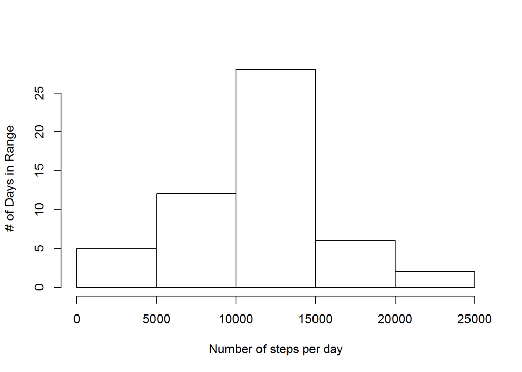

```r
hist(activitySummary$NumSteps, xlab = 'Number of steps per day', ylab = '# of Days in Range' , main = '')
```

#### The average number of steps in each interval is shown in the graph below

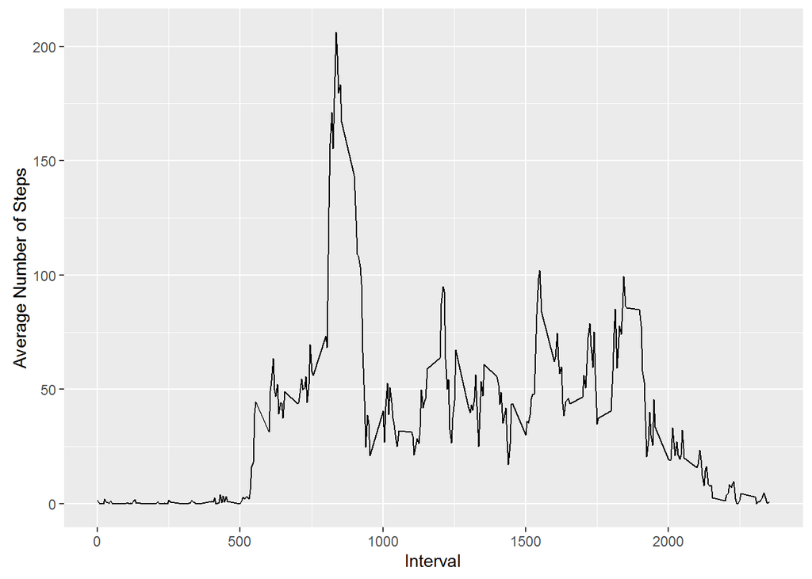

```r
intervalSummary <- activity1 %>% group_by(interval) %>% summarise(StepMean = mean(steps))

ggplot(aes(x = interval, y = StepMean), data = intervalSummary) + geom_line() + labs(x = 'Interval', y = 'Average Number of Steps')
```

```r
maxStepinterval <- intervalSummary$interval[which(intervalSummary$StepMean == max(intervalSummary$StepMean))]
```

#### The 5 minute interval containing the highest average number of steps is the 835th

### In this part of the analysis we’ll introduce the missing values back into the data.

#### First we determine how many rows have missing NA step data

```r
numMissing <- nrow(activity[is.na(activity$steps),])
```

#### The number of missing values in the data set is 2304

#### Then we will fill the missing values with the mean step count for that interval

```r
activityFull <- activity

for(i in 1:nrow(activityFull)){

  if( is.na(activityFull$steps[i]) ){
    intervalIndex <- which(intervalSummary$interval == activityFull$interval[i])
    activityFull$steps[i] <- intervalSummary$StepMean[intervalIndex]
  }
}

#Calculate the new total step count, mean, and median per day
activitySummaryFull <- activityFull %>% group_by(date) %>% summarise(NumSteps = sum(steps), StepMean = mean(steps), StepMedian = median(steps))
```

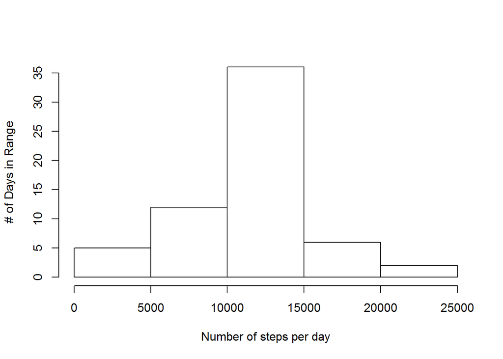

```r
hist(activitySummaryFull$NumSteps, xlab = 'Number of steps per day', ylab = '# of Days in Range' , main = '')
```

#### Looking at the above plot, it is very similar to the first, with the notable exception that the number of days that fall in the 10,000 - 15,000 step range is greater. By imputing the missing data we’ve increased the estimate of total daily steps.

### Weekdays vs Weekends

```r
activityFull$dateName <- weekdays(activityFull$date)

for(i in 1:length(activityFull$dateName)){

  if(activityFull$dateName[i] == 'Saturday' | activityFull$dateName[i] == 'Sunday'){
    activityFull$dateName[i] = 'Weekend'
  }
  else{
    activityFull$dateName[i] = 'Weekday'
  }
}

#Makes a two level factor column within activityFull
factor(activityFull$dateName)

intervalSummary <- activityFull %>% group_by(interval,dateName) %>% summarise(StepMean = mean(steps, na.rm = TRUE))
```

### Plot the average steps by interval, broken up by weekends and weekdays

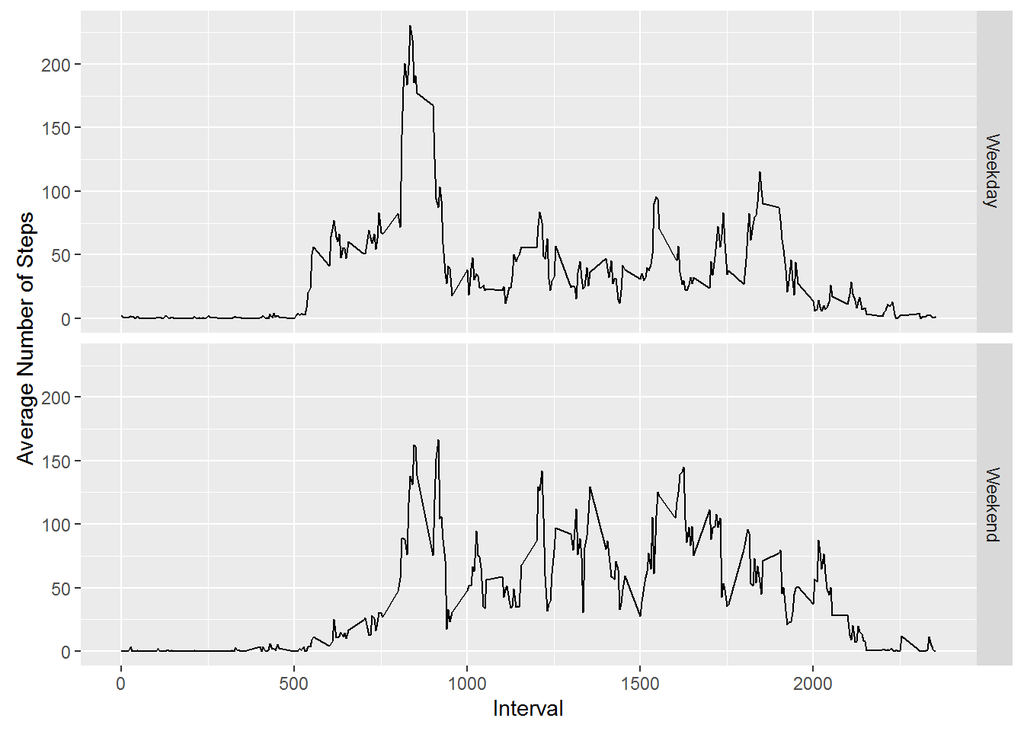

```r
ggplot(aes(x = interval, y = StepMean), data = intervalSummary) + geom_line() + labs(x = 'Interval', y = 'Average Number of Steps') + facet_grid(dateName~.)
```